# NOAA_WaterLvls_DepthAssessment

Louis Jochems

2024-04-30

EFB is found in coastal and inland wetland plant communities throughout the Great Lakes region. However, GL coastal wetlands are dynamic ecosystems, meaning that they fluctuate in community composition from year to year, largely due to varying water levels of the GL basin (due to natural fluctuations but more recently, extremes due to climate change; see work by Drew Gronewold). It is important to incorporate this dynamism into SDMs so that we can more accurately predict suitable habitat for EFB from year to year.

```r
options("sp_evolution_status" = 2)
library(sp)
library(sf)
library(terra)
library(sdm)
library(dplyr)
library(tidyr)
```

```r
library(ggplot2)
library(basemaps)
library(leaflet)
#library(ggmap)
library(lubridate)
library(ggsn)
library(viridis)
library(readr)

#rnoaa package to retrieve water levels from gauge stations
library(rnoaa)
# Set directory where point shape files are located
setwd("~/R/NOAAGreatLakes_WaterLevels")
#setwd("~/path/to/project/data")

# Read the full point dataset
sm_all <- read.csv("StMarysPts2015_23_FINAL_COMPLETE.csv")

# Read the point dataset with only extracted DEM values (important for later)
sm_dems <- read.csv("SM15_23ALLDEMs_NEW.csv")

#NOTE to CK: I generated this DEM dataframe in Arc bc it was easier for me to extract the merged DEMs
#there since Arc was available on a higher performing computer at BSU. So I don't have any R code for how to sample
#DEM values to points, BUT I could create a example of that workflow in an RMD file if you'd find that useful...
#let me know!
```

Loading in core packages for this project. Reading in necessary field data sets for the project as well. We have one that contains all field observations of EFB occurrence in our study area, the St. Mary’s River corridor in the Upper Peninsula, MI, USA, from 2015 - 2023. The other is the same points but only with extracted values from the following DEMs: NOAA Digital Coast LIDAR, USGS 3DEP 1m national (unprojected), and USGS (projected to same UTM as NOAA). We will join these values to the main dataframe so that we can then take the difference between the NOAA water levels and the topobathymetry/DEM to get a water depth column.

Here’s a quick plot to check the time series of daily water levels for each station by each year in study period:

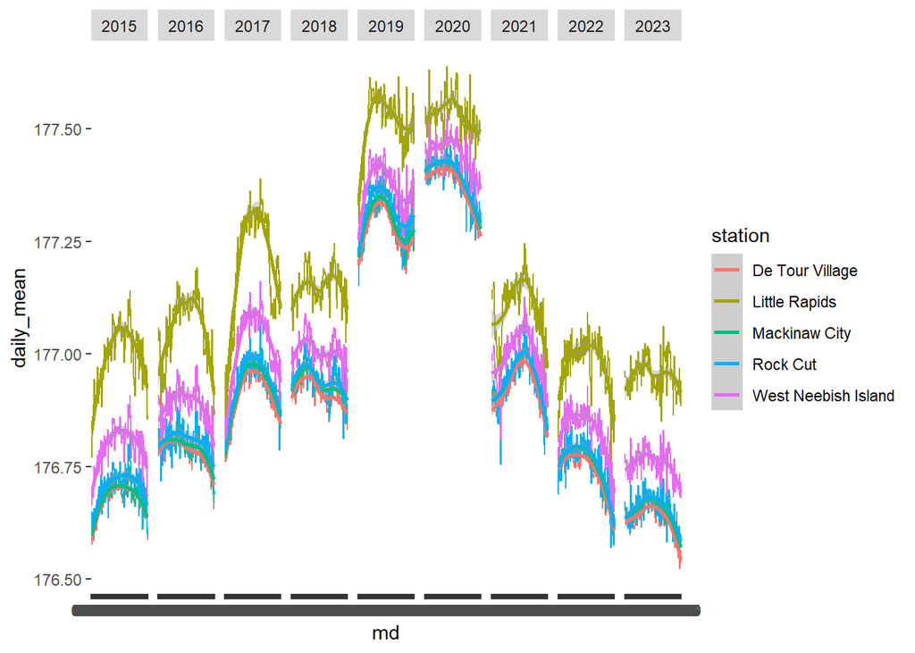

```r
ggplot(daily_df, aes(x = md, y = daily_mean, group = station, color = station)) +
  geom_line() +
  geom_smooth(method = "loess") +
  facet_grid(~year)
```

```r
#make a station sf (simple feature) real quick
station_name <- unique(daily_df$station)
gps_lat <- unique(daily_df$gps_lat)
gps_lon <- unique(daily_df$gps_lon)

station_df <- cbind(station_name,gps_lat,gps_lon) %>%
  as.data.frame()

#make gauge station shape file for making figure
station_sf <- st_as_sf(station_df,
                       coords = c("gps_lon","gps_lat"), crs = 4326)
#make gauge station shape file for making figure
#st_write(station_sf, "GaugeStations.shp")

#make of field observations sf
sm_sf <- st_as_sf(sm_all, coords = c("GPS_Lon", "GPS_Lat"), crs = 4326)

#extra packages for leaflet
library(htmlwidgets)
library(htmltools)
library(leaflet.extras)

north.arrow.file <- "<img src = 'https://upload.wikimedia.org/wikipedia/commons/a/aa/Aiga_uparrow.svg' style='width:40px;height:60px;'>"

map1 <- leaflet(sm_sf) %>%
  addProviderTiles('Esri.WorldImagery') %>%
  addMarkers(popup = ~hyd_bin) %>%
  addScaleBar(position="bottomright") %>%
  addControl(html=north.arrow.file,
             position="bottomleft",
             className="fieldset{}") %>%
  addMiniMap()

map2 <- leaflet(station_sf) %>%
  addProviderTiles('Esri.WorldImagery') %>%
  addMarkers(popup = ~station_name) %>%
  addScaleBar(position="bottomright") %>%
  addControl(html=north.arrow.file,
             position="bottomleft",
             className="fieldset{}") %>%
  addMiniMap()

# Arrange the maps side by side manually in an HTML layout
div(
  div(map1, style = "width: 50%; float: left;"),
  div(map2, style = "width: 50%; float: left;")
)
```

[interactive chart not shown]

Looks like a handful of points are fairly close to Little Rapids with elevated water levels. Keep in mind for later. May need to unpack this further for manuscript.

For now, we will extract monthly water levels to all observations.

```r
#same stations as above
# Initialize a new list to store monthly results
results_monthly <- list()

# Loop through each station and year to fetch monthly data
for (sid in unique(station_ids)) {
  for (year in 2015:2023) {
    data <- coops_search(
      station_name = sid,
      begin_date = paste0(year, '0601'),
      end_date = paste0(year, '0930'),
      datum = "stnd",
      product = "monthly_mean", # Fetch monthly means
      units = "metric",
      time_zone = "lst",
      application = "rnoaa")
    # Add station metadata to the data
    data$data$station <- data$metadata$name
    data$data$gps_lat <- data$metadata$lat
    data$data$gps_lon <- data$metadata$lon
    data$data$station_num <- data$metadata$id
    # Store data in a list
    results_monthly[[length(results_monthly) + 1]] <- data #repeat for all stations
  }
}

# Extract and combine into one big dataframe
monthlies <- lapply(results_monthly, function(x) x$data)
monthly_df <- do.call(rbind, monthlies) %>%
  select(-c(MHHW, MHW, MTL, MLW, MLLW, DTL, GT, MN, DHQ, DLQ, HWI, LWI, inferred)) # Drop columns with NA values
```

Now that we have grabbed daily and monthly water levels, we can calculate nearest neighbor distances for all field observations to the station locations.

```r
library(FNN)

#station means will be quickest for calculating NN (presumably)
#using monthly df because it doesn't really matter for FNN function
#station coords the same for monthly or daily
monthly_means <- aggregate(cbind(highest, MSL,lowest) ~
                            station + gps_lat + gps_lon,
                           data = monthly_df, mean)

monthly_means$ID <- 1:5 #going with five stations now, excluded "US Slip"

#make gps_lat, gps_lon numeric, NOT characters (necessary for nn function)
monthly_means <- monthly_means %>%
  mutate(gps_lat = as.numeric(gps_lat),
         gps_lon = as.numeric(gps_lon))

fnn <- as.data.frame(get.knnx(monthly_means[,c(3, 2)],
                              sm_all[,c(11, 12)],
                              k = 4))
#REMEMBER coord order make sure they match up: long then lat
#output is in dec degrees, but shouldn't matter?
#k = 4 nearest neighbors

#append nearest station index to main df
sm_all$station_id <- fnn$nn.index.1

#Code below commented out just because it was a test for the daily df
#I think it will be the same nearest station IDs for dailies, but would like to double check
# daily_means <- aggregate(daily_mean ~
#                             station + gps_lat + gps_lon,
#                            data = daily_df, mean)
# daily_means$ID <- 1:6 #six stations now
#
# #make gps_lat, gps_lon numeric, not characters (necessary for nn function)
# daily_means <- daily_means %>%
#   mutate(gps_lat = as.numeric(gps_lat),
#          gps_lon = as.numeric(gps_lon))
#
# fnn_daily <- as.data.frame(get.knnx(daily_means[,c(3,2)], sm_all[,c(10,11)], k=4))
#
# identical(fnn,fnn_daily)
#[1] TRUE
#confirmed
```

Since we’ve attached the index of the nearest station to each point in the main dataframe, we can then do an inner_join of the fnn objects to the dataframe and get the monthly/daily water levels for each station.

```r
######------dailies------######
#add station id column for matching and joining
daily_df$station_id <- NA %>%
  as.double()

# Add new station indices to daily_df
daily_df <- daily_df %>%
  mutate(
    station_id = case_when(
      station == "De Tour Village" ~ 1,
      station == "Rock Cut" ~ 2,
      station == "West Neebish Island" ~ 3,
      station == "Mackinaw City" ~ 4,
      station == "Little Rapids" ~ 5,
      TRUE ~ station_id  # Keep station_id unchanged for other stations
    )
  )
#now try inner_join, should work based on date alone
#make station id in main df numeric
sm_all$station_id <- as.numeric(sm_all$station_id)

sm_all$date <- as.Date(sm_all$date)
daily_df$date <- as.Date(daily_df$date)

#join dailies to main df
sm_all_wl <- dplyr::inner_join(sm_all, daily_df, by = c("station_id", "date"))

#need to rename, drop, and wrangle some columns to avoid confusion
sm_all_wl <- sm_all_wl %>%
  select(-c(Station, Year)) #drop old Station column bc doesn't contain '23 data, Year is redundant

#####------ onto monthly's -----######
#add station id column for matching and joining
monthly_df$station_id <- NA %>%
  as.double()

# Add new station indices to monthly_df
monthly_df <- monthly_df %>%
  mutate(
    station_id = case_when(
      station == "De Tour Village" ~ 1,
      station == "Rock Cut" ~ 2,
      station == "West Neebish Island" ~ 3,
      station == "Mackinaw City" ~ 4,
      station == "Little Rapids" ~ 5,
      TRUE ~ station_id  # Keep station_id unchanged for other stations
    )
  )

sm_all_wl <- dplyr::inner_join(sm_all_wl, monthly_df,
                                    by = c("station_id", "month", "year"))
#now we have daily means, as well as highest/lowest & mean MONTHLY water levels for each point. nice!

#more wrangling
sm_all_wl <- sm_all_wl %>%
  select(-c(station.y, gps_lat.y, gps_lon.y, station_num.y, X.2)) #drop redundant columns

#rename some columns to avoid confusion
names(sm_all_wl)[59:63] <- c("Daily_WL","NOAA_Station","station_lat",
                             "station_lon","station_num")
names(sm_all_wl)[66:68] <- c("HWL_Monthly","MWL_Monthly","LWL_Monthly") #high, mean, low
```

The relevant water levels are now added to the main dataframe of EFB observations. Next, we need to add DEM values to this dataframe, calculate water depth by taking the difference of the NOAA water level and the DEM value.

```r
#first name columns in dem df
names(sm_dems)[c(2:7)] <- c("X.1", "GPS_Lon", "GPS_Lat",
                            "Topobathymetry","Elev_unproj","Elev_proj")

#drop the old dem columns in main df
sm_all_wl <- sm_all_wl %>%
  select(-c(dem_source,Topobathymetry,elevation,Topo_DEM,
            High_WL,Mean_WL,Low_WL,Final_HD,Final_MD,Final_LD))

#reorder columns
sm_all_wl <- sm_all_wl %>%
  select(
    X.1, X, OID_1, date, year, month, md, source, Lon_UTM, Lat_UTM, GPS_Lon, GPS_Lat, dst_typ, humn_md, hyd_bin,
    EFB_cover, phrg_bn, tg_bin, typ_bin, typ_cvr, emrg_bin, water_depth, Near_Dist, MeanFetch, MeanREI, SummerNDVI,
    SummerNDWI, SummerVH_mean, SummerVH_VV_mean, SummerVV_mean, correctedVH, correctedVV, correctedVVVH, correctedVHVV,
    smoothVH, smoothVHVV, smoothVV, waypoint, veg_zone, dom_spp, dom_cov, sec_spp, sec_cov, notes,
    ORG_DEP, SCH_D, TYP_D, station_id, Daily_WL, NOAA_Station, station_lat, station_lon, station_num, HWL_Monthly,
    MWL_Monthly, LWL_Monthly
  )
#drop gps_elev & unit columns. Not very useful

#now add dems to main df, join by unique ID X.1
sm_wldems <- left_join(sm_all_wl, sm_dems,
                       by = c("X.1"))
#gps don't quite match (even though they do by the eye?)
#maybe bc arcgis spat out not quite same coords when
#extracting DEMs to new df? keep in mind

#dem source column
sm_wldems$dem_source <- ifelse(sm_wldems$Topobathymetry > 0,
                               "NOAA_USACE", NA)
sm_wldems$dem_source <- ifelse(is.na(sm_wldems$dem_source) & sm_wldems$Elev_unproj > 0,
                               "USGS", sm_wldems$dem_source)
#sm_wldems %>% count(dem_source)
#47 missing either dem source, but will just leave em for now

#make final dem/topo column
sm_wldems$Topo_DEM <- sm_wldems$Topobathymetry
#add projected elevation bc it has no zeros
sm_wldems$Topo_DEM <- ifelse(sm_wldems$Topo_DEM == -9999.0000, sm_wldems$Elev_proj,
                             sm_wldems$Topo_DEM)
#will still assess unprojected though

#make all -9999's into NAs. probably better this way
sm_wldems[sm_wldems == -9999.0000] <- NA

#create final depth for each water level: highest, mean, lowest monthly,
#AND DAILY... minus Topo_DEM
sm_wldems <- sm_wldems %>%
  mutate(Monthly_HD = HWL_Monthly - Topo_DEM) %>%
  mutate(Monthly_MD = MWL_Monthly - Topo_DEM) %>%
  mutate(Monthly_LD = LWL_Monthly - Topo_DEM) %>%
  mutate(Daily_D = Daily_WL - Topo_DEM)

# > nrow(sdm_usgs[which(sdm_usgs$Monthly_HD > 0),])
# [1] 1017
# > nrow(sdm_usgs[which(sdm_usgs$Final_MD > 0),])
# [1] 939
# > nrow(sdm_usgs[which(sdm_usgs$Final_LD > 0),])
# [1] 788

#drop a few more extraneous columns
sm_wldems <- sm_wldems %>%
  select(-c(waypoint,OID_,GPS_Lon.y,GPS_Lat.y))

# make a new typha column for assessment purposes
# rework typha density column
sm_wldems$TYP_D <- ifelse(is.na(sm_wldems$TYP_D) | sm_wldems$TYP_D == "N/A", 0,
                          sm_wldems$TYP_D) %>% as.numeric()

sm_wldems$typ_total <- sm_wldems$typ_cvr + as.integer(sm_wldems$TYP_D)
# still get NA's to zero in final column
# write.csv(sm_wldems,"StMarysALL_wRSDepths.csv")
```

We now have a dataframe with highest, mean, lowest monthly water depths, as well as daily mean water depths for each point. Now look at relationships of these RS derived depths with in situ depths.

```r
library(ggpubr) #need for ggscatter()
```

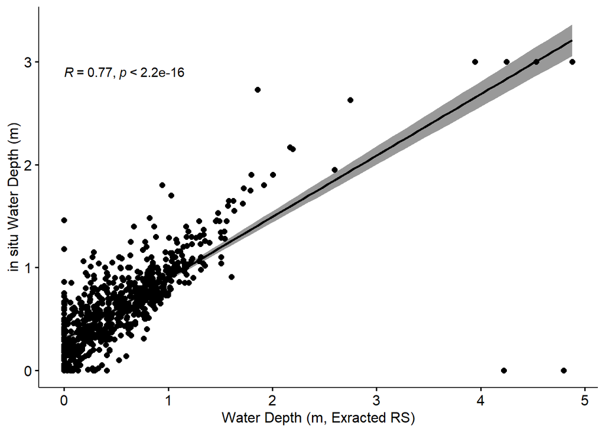

```r
depths_noaa <- sm_wldems %>%
  filter(dem_source == "NOAA_USACE") %>%
  filter(!is.na(water_depth)) %>%
  filter(Monthly_HD > -0.5)

#set as zero for all depths
pos_func <- function(x) {
  x$Monthly_HD<- ifelse(x$Monthly_HD < 0, 0, x$Monthly_HD)
  x$Monthly_MD <- ifelse(x$Monthly_MD < 0, 0, x$Monthly_MD)
  x$Monthly_LD <- ifelse(x$Monthly_LD < 0, 0, x$Monthly_LD)
  return(x)
}

depth <- pos_func(depths_noaa)
depth$water_depth <- as.numeric(depth$water_depth)
depth$water_depth <- (depth$water_depth)/100

wd_plot <- ggscatter(depth, x = "Monthly_HD",
                     y = "water_depth", add = "reg.line", conf.int = TRUE,
                     cor.coef = TRUE, cor.method = "pearson",
                     xlab = "Water Depth (m, Exracted RS)",
                     ylab = "in situ Water Depth (m)",na.rm = TRUE)

wd_plot
```

The RS and in situ RS depths show a positive linear relationship!